# Project: Investigate a Dataset - [TMDb movie data]

- Introduction
- Data Wrangling
- Exploratory Data Analysis
- Conclusions

## Introduction

### Dataset Description

> The dataset selected for this mini project is the TMDB movie database. The reason why I chose to analyze this data set is that it is very convinient and alligns with the beginner level. Through my Analysis I attempted to detect and draw trends between diffierent features.

### Question(s) for Analysis

> Four main questions I thought were suitable for this analysis; the first one inquires about the evolution of profits through the years, the second question investigates the average profit engendered by each category, the third inquiry shows the most popular directors and the last question depicts the top rated movie categories.

### Data Set attributes and features

```python
#Importing packages
import numpy as np
import pandas as pd
import matplotlib.pyplot as plt
import seaborn as sns
%matplotlib inline
```

## Data Wrangling

```python
df = pd.read_csv(r'C:\Users\USER\Desktop\Data\tmdb-movies.csv') # Kindly edit this when reviewing my project.
```

```python
df.head(10)
```

|  | id | imdb_id | popularity | budget | revenue | original_title | cast | homepage | director | tagline | ... | overview | runtime | genres | production_companies | release_date | vote_count | vote_average | release_year | budget_adj | revenue_adj |
| --- | --- | --- | --- | --- | --- | --- | --- | --- | --- | --- | --- | --- | --- | --- | --- | --- | --- | --- | --- | --- | --- |
| 0 | 135397 | tt0369610 | 32.985763 | 150000000 | 1513528810 | Jurassic World | Chris Pratt\|Bryce Dallas Howard\|Irrfan Khan\|Vi... | http://www.jurassicworld.com/ | Colin Trevorrow | The park is open. | ... | Twenty-two years after the events of Jurassic ... | 124 | Action\|Adventure\|Science Fiction\|Thriller | Universal Studios\|Amblin Entertainment\|Legenda... | 6/9/15 | 5562 | 6.5 | 2015 | 1.379999e+08 | 1.392446e+09 |
| 1 | 76341 | tt1392190 | 28.419936 | 150000000 | 378436354 | Mad Max: Fury Road | Tom Hardy\|Charlize Theron\|Hugh Keays-Byrne\|Nic... | http://www.madmaxmovie.com/ | George Miller | What a Lovely Day. | ... | An apocalyptic story set in the furthest reach... | 120 | Action\|Adventure\|Science Fiction\|Thriller | Village Roadshow Pictures\|Kennedy Miller Produ... | 5/13/15 | 6185 | 7.1 | 2015 | 1.379999e+08 | 3.481613e+08 |
| 2 | 262500 | tt2908446 | 13.112507 | 110000000 | 295238201 | Insurgent | Shailene Woodley\|Theo James\|Kate Winslet\|Ansel... | http://www.thedivergentseries.movie/#insurgent | Robert Schwentke | One Choice Can Destroy You | ... | Beatrice Prior must confront her inner demons ... | 119 | Adventure\|Science Fiction\|Thriller | Summit Entertainment\|Mandeville Films\|Red Wago... | 3/18/15 | 2480 | 6.3 | 2015 | 1.012000e+08 | 2.716190e+08 |
| 3 | 140607 | tt2488496 | 11.173104 | 200000000 | 2068178225 | Star Wars: The Force Awakens | Harrison Ford\|Mark Hamill\|Carrie Fisher\|Adam D... | http://www.starwars.com/films/star-wars-episod... | J.J. Abrams | Every generation has a story. | ... | Thirty years after defeating the Galactic Empi... | 136 | Action\|Adventure\|Science Fiction\|Fantasy | Lucasfilm\|Truenorth Productions\|Bad Robot | 12/15/15 | 5292 | 7.5 | 2015 | 1.839999e+08 | 1.902723e+09 |
| 4 | 168259 | tt2820852 | 9.335014 | 190000000 | 1506249360 | Furious 7 | Vin Diesel\|Paul Walker\|Jason Statham\|Michelle ... | http://www.furious7.com/ | James Wan | Vengeance Hits Home | ... | Deckard Shaw seeks revenge against Dominic Tor... | 137 | Action\|Crime\|Thriller | Universal Pictures\|Original Film\|Media Rights ... | 4/1/15 | 2947 | 7.3 | 2015 | 1.747999e+08 | 1.385749e+09 |
| 5 | 281957 | tt1663202 | 9.110700 | 135000000 | 532950503 | The Revenant | Leonardo DiCaprio\|Tom Hardy\|Will Poulter\|Domhn... | http://www.foxmovies.com/movies/the-revenant | Alejandro González Iñárritu | (n. One who has returned, as if from the dead.) | ... | In the 1820s, a frontiersman, Hugh Glass, sets... | 156 | Western\|Drama\|Adventure\|Thriller | Regency Enterprises\|Appian Way\|CatchPlay\|Anony... | 12/25/15 | 3929 | 7.2 | 2015 | 1.241999e+08 | 4.903142e+08 |
| 6 | 87101 | tt1340138 | 8.654359 | 155000000 | 440603537 | Terminator Genisys | Arnold Schwarzenegger\|Jason Clarke\|Emilia Clar... | http://www.terminatormovie.com/ | Alan Taylor | Reset the future | ... | The year is 2029. John Connor, leader of the r... | 125 | Science Fiction\|Action\|Thriller\|Adventure | Paramount Pictures\|Skydance Productions | 6/23/15 | 2598 | 5.8 | 2015 | 1.425999e+08 | 4.053551e+08 |
| 7 | 286217 | tt3659388 | 7.667400 | 108000000 | 595380321 | The Martian | Matt Damon\|Jessica Chastain\|Kristen Wiig\|Jeff ... | http://www.foxmovies.com/movies/the-martian | Ridley Scott | Bring Him Home | ... | During a manned mission to Mars, Astronaut Mar... | 141 | Drama\|Adventure\|Science Fiction | Twentieth Century Fox Film Corporation\|Scott F... | 9/30/15 | 4572 | 7.6 | 2015 | 9.935996e+07 | 5.477497e+08 |
| 8 | 211672 | tt2293640 | 7.404165 | 74000000 | 1156730962 | Minions | Sandra Bullock\|Jon Hamm\|Michael Keaton\|Allison... | http://www.minionsmovie.com/ | Kyle Balda\|Pierre Coffin | Before Gru, they had a history of bad bosses | ... | Minions Stuart, Kevin and Bob are recruited by... | 91 | Family\|Animation\|Adventure\|Comedy | Universal Pictures\|Illumination Entertainment | 6/17/15 | 2893 | 6.5 | 2015 | 6.807997e+07 | 1.064192e+09 |
| 9 | 150540 | tt2096673 | 6.326804 | 175000000 | 853708609 | Inside Out | Amy Poehler\|Phyllis Smith\|Richard Kind\|Bill Ha... | http://movies.disney.com/inside-out | Pete Docter | Meet the little voices inside your head. | ... | Growing up can be a bumpy road, and it's no ex... | 94 | Comedy\|Animation\|Family | Walt Disney Pictures\|Pixar Animation Studios\|W... | 6/9/15 | 3935 | 8.0 | 2015 | 1.609999e+08 | 7.854116e+08 |

10 rows × 21 columns

```python
#Fetching info about the dataset
```

```python
df.info()
```

```
<class 'pandas.core.frame.DataFrame'>
RangeIndex: 10866 entries, 0 to 10865
Data columns (total 21 columns):
 #   Column                Non-Null Count  Dtype
---  ------                --------------  -----
 0   id                    10866 non-null  int64
 1   imdb_id               10856 non-null  object
 2   popularity            10866 non-null  float64
 3   budget                10866 non-null  int64
 4   revenue               10866 non-null  int64
 5   original_title        10866 non-null  object
 6   cast                  10790 non-null  object
 7   homepage              2936 non-null   object
 8   director              10822 non-null  object
 9   tagline               8042 non-null   object
 10  keywords              9373 non-null   object
 11  overview              10862 non-null  object
 12  runtime               10866 non-null  int64
 13  genres                10843 non-null  object
 14  production_companies  9836 non-null   object
 15  release_date          10866 non-null  object
 16  vote_count            10866 non-null  int64
 17  vote_average          10866 non-null  float64
 18  release_year          10866 non-null  int64
 19  budget_adj            10866 non-null  float64
 20  revenue_adj           10866 non-null  float64
dtypes: float64(4), int64(6), object(11)
memory usage: 1.7+ MB
```

> We can see that there are features that won't really be handy into helping us analyzing our datasets, we will eventually drop them as a first step.

```python
#Drop unecessary columns
df.drop(['imdb_id', 'homepage', 'tagline', 'keywords', 'overview', 'budget_adj', 'revenue_adj' ], axis=1, inplace=True)
```

```python
df.info()
```

```
<class 'pandas.core.frame.DataFrame'>
RangeIndex: 10866 entries, 0 to 10865
Data columns (total 14 columns):
 #   Column                Non-Null Count  Dtype
---  ------                --------------  -----
 0   id                    10866 non-null  int64
 1   popularity            10866 non-null  float64
 2   budget                10866 non-null  int64
 3   revenue               10866 non-null  int64
 4   original_title        10866 non-null  object
 5   cast                  10790 non-null  object
 6   director              10822 non-null  object
 7   runtime               10866 non-null  int64
 8   genres                10843 non-null  object
 9   production_companies  9836 non-null   object
 10  release_date          10866 non-null  object
 11  vote_count            10866 non-null  int64
 12  vote_average          10866 non-null  float64
 13  release_year          10866 non-null  int64
dtypes: float64(2), int64(6), object(6)
memory usage: 1.2+ MB
```

> Next we're gonna start cleaning our dataset, first by looking up duplicates

```python
# check for duplicates in the data
sum(df.duplicated())
```

```
1
```

> There is a duplicate row that we need to drop, we'll do that below:

```python
# drop duplicates
df.drop_duplicates(inplace = True)
```

> Now we will look for null/empty cells

```python
df.isnull().sum()
```

```
id                         0
popularity                 0
budget                     0
revenue                    0
original_title             0
cast                      76
director                  44
runtime                    0
genres                    23
production_companies    1030
release_date               0
vote_count                 0
vote_average               0
release_year               0
dtype: int64
```

```python
df.dropna(axis=0, inplace=True)
```

> We now check the shape of our dataset

```python
df.shape
```

```
(9772, 14)
```

> We will add a new column under the name profit that we will use later in the exploratory analysis

```python
#Add new column profit
df['profit'] = df['revenue'] - df['budget']
```

```python
# confirm changes
df.dtypes
```

```
id                        int64
popularity              float64
budget                    int64
revenue                   int64
original_title           object
cast                     object
director                 object
runtime                   int64
genres                   object
production_companies     object
release_date             object
vote_count                int64
vote_average            float64
release_year              int64
profit                    int64
dtype: object
```

```python
df
```

|  | id | popularity | budget | revenue | original_title | cast | director | runtime | genres | production_companies | release_date | vote_count | vote_average | release_year | profit |
| --- | --- | --- | --- | --- | --- | --- | --- | --- | --- | --- | --- | --- | --- | --- | --- |
| 0 | 135397 | 32.985763 | 150000000 | 1513528810 | Jurassic World | Chris Pratt\|Bryce Dallas Howard\|Irrfan Khan\|Vi... | Colin Trevorrow | 124 | Action\|Adventure\|Science Fiction\|Thriller | Universal Studios\|Amblin Entertainment\|Legenda... | 6/9/15 | 5562 | 6.5 | 2015 | 1363528810 |
| 1 | 76341 | 28.419936 | 150000000 | 378436354 | Mad Max: Fury Road | Tom Hardy\|Charlize Theron\|Hugh Keays-Byrne\|Nic... | George Miller | 120 | Action\|Adventure\|Science Fiction\|Thriller | Village Roadshow Pictures\|Kennedy Miller Produ... | 5/13/15 | 6185 | 7.1 | 2015 | 228436354 |
| 2 | 262500 | 13.112507 | 110000000 | 295238201 | Insurgent | Shailene Woodley\|Theo James\|Kate Winslet\|Ansel... | Robert Schwentke | 119 | Adventure\|Science Fiction\|Thriller | Summit Entertainment\|Mandeville Films\|Red Wago... | 3/18/15 | 2480 | 6.3 | 2015 | 185238201 |
| 3 | 140607 | 11.173104 | 200000000 | 2068178225 | Star Wars: The Force Awakens | Harrison Ford\|Mark Hamill\|Carrie Fisher\|Adam D... | J.J. Abrams | 136 | Action\|Adventure\|Science Fiction\|Fantasy | Lucasfilm\|Truenorth Productions\|Bad Robot | 12/15/15 | 5292 | 7.5 | 2015 | 1868178225 |
| 4 | 168259 | 9.335014 | 190000000 | 1506249360 | Furious 7 | Vin Diesel\|Paul Walker\|Jason Statham\|Michelle ... | James Wan | 137 | Action\|Crime\|Thriller | Universal Pictures\|Original Film\|Media Rights ... | 4/1/15 | 2947 | 7.3 | 2015 | 1316249360 |
| ... | ... | ... | ... | ... | ... | ... | ... | ... | ... | ... | ... | ... | ... | ... | ... |
| 10861 | 21 | 0.080598 | 0 | 0 | The Endless Summer | Michael Hynson\|Robert August\|Lord 'Tally Ho' B... | Bruce Brown | 95 | Documentary | Bruce Brown Films | 6/15/66 | 11 | 7.4 | 1966 | 0 |
| 10862 | 20379 | 0.065543 | 0 | 0 | Grand Prix | James Garner\|Eva Marie Saint\|Yves Montand\|Tosh... | John Frankenheimer | 176 | Action\|Adventure\|Drama | Cherokee Productions\|Joel Productions\|Douglas ... | 12/21/66 | 20 | 5.7 | 1966 | 0 |
| 10863 | 39768 | 0.065141 | 0 | 0 | Beregis Avtomobilya | Innokentiy Smoktunovskiy\|Oleg Efremov\|Georgi Z... | Eldar Ryazanov | 94 | Mystery\|Comedy | Mosfilm | 1/1/66 | 11 | 6.5 | 1966 | 0 |
| 10864 | 21449 | 0.064317 | 0 | 0 | What's Up, Tiger Lily? | Tatsuya Mihashi\|Akiko Wakabayashi\|Mie Hama\|Joh... | Woody Allen | 80 | Action\|Comedy | Benedict Pictures Corp. | 11/2/66 | 22 | 5.4 | 1966 | 0 |
| 10865 | 22293 | 0.035919 | 19000 | 0 | Manos: The Hands of Fate | Harold P. Warren\|Tom Neyman\|John Reynolds\|Dian... | Harold P. Warren | 74 | Horror | Norm-Iris | 11/15/66 | 15 | 1.5 | 1966 | -19000 |

9772 rows × 15 columns

> For convinience reasons, and to make my analysis easy, I will only take into consideration the first genre of the movie and hence only the first genre in the genres' column is taken into consideration. The code used is the same learned when we dividied the rows containing two fuel types.

```python
#We make a clone of our original dataset
df1 = df.copy()
# columns to split by "|"
split_columns = ['genres']
# apply split function to each column of each dataframe copy
for c in split_columns:
    df1[c] = df1[c].apply(lambda x: x.split("|")[0])
```

```python
#We make sure our dataset is edited
df1.head()
```

|  | id | popularity | budget | revenue | original_title | cast | director | runtime | genres | production_companies | release_date | vote_count | vote_average | release_year | profit |
| --- | --- | --- | --- | --- | --- | --- | --- | --- | --- | --- | --- | --- | --- | --- | --- |
| 0 | 135397 | 32.985763 | 150000000 | 1513528810 | Jurassic World | Chris Pratt\|Bryce Dallas Howard\|Irrfan Khan\|Vi... | Colin Trevorrow | 124 | Action | Universal Studios\|Amblin Entertainment\|Legenda... | 6/9/15 | 5562 | 6.5 | 2015 | 1363528810 |
| 1 | 76341 | 28.419936 | 150000000 | 378436354 | Mad Max: Fury Road | Tom Hardy\|Charlize Theron\|Hugh Keays-Byrne\|Nic... | George Miller | 120 | Action | Village Roadshow Pictures\|Kennedy Miller Produ... | 5/13/15 | 6185 | 7.1 | 2015 | 228436354 |
| 2 | 262500 | 13.112507 | 110000000 | 295238201 | Insurgent | Shailene Woodley\|Theo James\|Kate Winslet\|Ansel... | Robert Schwentke | 119 | Adventure | Summit Entertainment\|Mandeville Films\|Red Wago... | 3/18/15 | 2480 | 6.3 | 2015 | 185238201 |
| 3 | 140607 | 11.173104 | 200000000 | 2068178225 | Star Wars: The Force Awakens | Harrison Ford\|Mark Hamill\|Carrie Fisher\|Adam D... | J.J. Abrams | 136 | Action | Lucasfilm\|Truenorth Productions\|Bad Robot | 12/15/15 | 5292 | 7.5 | 2015 | 1868178225 |
| 4 | 168259 | 9.335014 | 190000000 | 1506249360 | Furious 7 | Vin Diesel\|Paul Walker\|Jason Statham\|Michelle ... | James Wan | 137 | Action | Universal Pictures\|Original Film\|Media Rights ... | 4/1/15 | 2947 | 7.3 | 2015 | 1316249360 |

## Exploratory Data Analysis

### Univariante analysis

#### Let's explore the outliers that exist within the revenue and budget columns

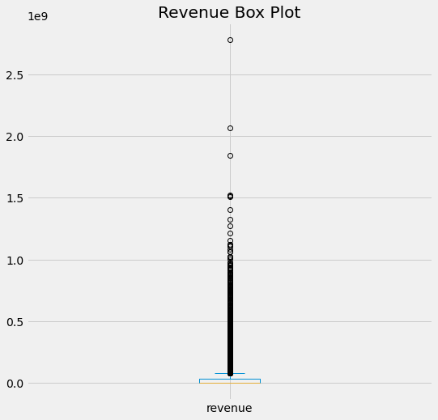

```python
#box plot for the revenue
df1['revenue'].plot(kind='box', figsize= (8,8));
plt.title('Revenue Box Plot')
```

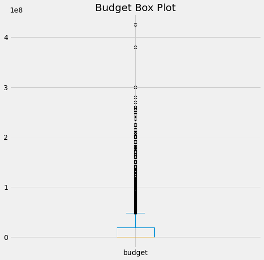

```python
#box plot for the budget
df1['budget'].plot(kind='box', figsize= (8,8));
plt.title('Budget Box Plot')
```

#### Investigating the distribution of both release year and vote_average columns

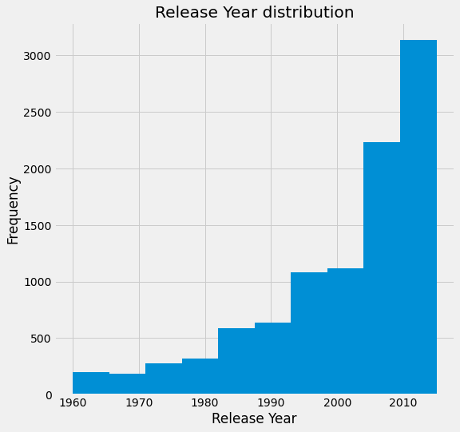

```python
# plot distribution of release year
df1['release_year'].plot(kind='hist', figsize= (8,8));
plt.title('Release Year distribution')
plt.xlabel('Release Year');
```

#### It is safe to conclude that most films were produced in the 21 first century. In 2010 and the yers that follow, the production of movies have witnessed an enormous increase.

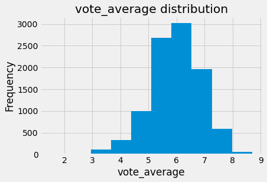

```python
df1['vote_average'].plot(kind='hist');
plt.title('vote_average distribution')
plt.xlabel('vote_average');
```

#### The most recurrent average votes are between 5 and 7.

### Bivariante analysis

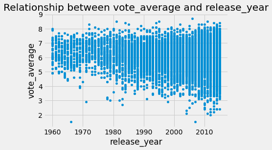

```python
# Plot relationship between vote average and release_year
plot1 = df.plot(x= 'release_year', y='vote_average', kind='scatter')
plt.title('Relationship between vote_average and release_year');
```

### How is the yearly profit evolving with the years?

> In order to solve this questions we will need to use group by and specify the argument as 'release_year', then the sum of profit and of course plot the result.

```python
#Sum generated within the years
```

```python
#Setting Style first ( I learned this on data)
plt.style.use('fivethirtyeight')
```

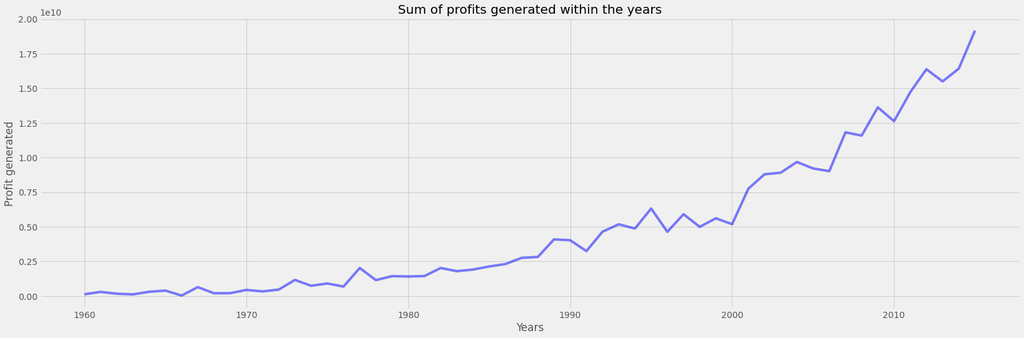

```python
df1.groupby('release_year').profit.sum().plot(kind='line', alpha = 0.5, color= 'blue');
plt.title('Sum of profits generated within the years')
plt.xlabel('Years')
plt.ylabel('Profit generated');
```

It is clear that through the years, the profit generated by the cinema industry is gradually increasing.

### What movie genres generate the most profits?

> In an effort to solve this question we will group by using the movie genre and see the mean profit generated by each genre.

```python
# Use groupby to get the mean profit for each category
Gen_Profmeans = df1.groupby('genres').profit.mean()
Gen_Profmeans
```

```
genres
Action             3.888634e+07
Adventure          8.999286e+07
Animation          5.817231e+07
Comedy             2.109506e+07
Crime              2.110630e+07
Documentary        2.425478e+06
Drama              1.639473e+07
Family             4.856691e+07
Fantasy            4.718895e+07
Foreign            0.000000e+00
History            3.207047e+07
Horror             1.207691e+07
Music              1.585337e+07
Mystery            1.514059e+07
Romance            3.106216e+07
Science Fiction    5.955409e+07
TV Movie           3.813559e+05
Thriller           1.482176e+07
War                2.388319e+07
Western            1.157395e+07
Name: profit, dtype: float64
```

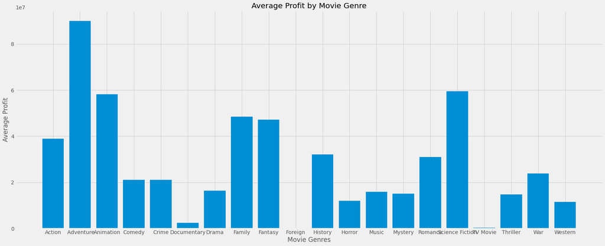

```python
# Create a bar chart with proper labels
locations = [1, 2, 3, 4, 5,6,7,8,9,10,11,12,13,14,15,16,17,18,19,20]
heights = Gen_Profmeans

labels = ['Action',' Adventure', 'Animation', 'Comedy' ,'Crime' ,'Documentary' ,'Drama' ,'Family', 'Fantasy' ,'Foreign' ,'History' ,'Horror' ,'Music' ,'Mystery' ,'Romance' ,'Science Fiction' ,'TV Movie' ,'Thriller' ,'War' ,'Western']
f, ax = plt.subplots(figsize=(25,10))
plt.bar(locations, heights, tick_label=labels)
plt.title('Average Profit by Movie Genre')
plt.xlabel('Movie Genres')
plt.ylabel('Average Profit');
```

> As show in the bar plot, the genre that ranks first in generating meontary gains is the Adventure genre.

### Who are the most popular directors?

To approach this question, I first applied a mask where I only included the top rated movies, I then used group by to plot the directors as well as their popularity.

```python
df_top = df1.query('vote_average >= 8')
df_top.shape
```

```
(60, 15)
```

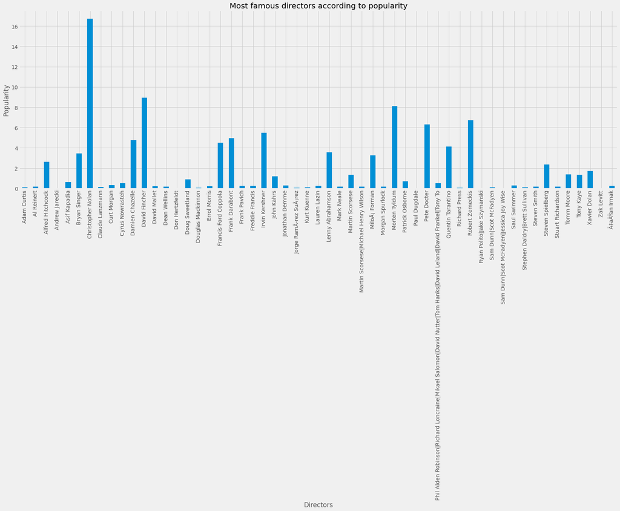

```python
df_top.groupby('director').popularity.mean().plot(kind='bar');
plt.rcParams["figure.figsize"] = (25,8)
plt.title('Most famous directors according to popularity')
plt.xlabel('Directors')
plt.ylabel('Popularity');
```

### What are the most famous movie genres?

> Here I used the value count predefined function to see, in the top movies dataset, the most famous movie genres that had the best ratings.

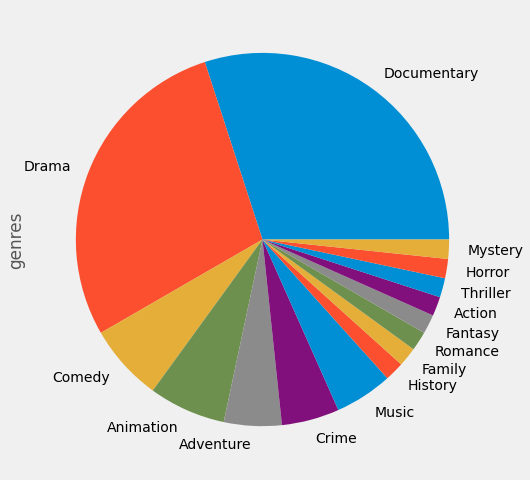

```python
df_top.genres.value_counts().plot(kind='pie', figsize= (8,8)); #pie chart
```

## Limitation

> One of the limitation I found is the absence of the gender of the reviewers. Providing the gender will help draw in more conclusions such as: what gender is more fond of cinema? what gender is more attracted to a certain movie category? What gender is more likely to give good reviews and what gender has a propensity to give poor reviews?